# Using different ODE solves with dMod

Daniel Kaschek

dMod uses the cOde package to simulate ODEs. The cOde package is a wrapper package for deSolve, automatically creating and compiling ODEs as C code to be directly used by deSolve. This means that in dMod, all ODE solvers which are implemented in deSolve can be used. Here, we show how:

```r
library(dMod)
library(dplyr)
setwd(tempdir())
```

We begin with defining ODEs and creating an ODE model from the equations.

```r
# Linear chain
equations <- eqnvec(
  INPUT = "0",
  Comp1 = "k_tr*INPUT - k_tr*Comp1",
  Comp2 = "k_tr*Comp1 - k_tr*Comp2",
  Comp3 = "k_tr*Comp2 - k_tr*Comp3",
  Comp4 = "k_tr*Comp3 - k_tr*Comp4",
  Comp5 = "k_tr*Comp4 - k_tr*Comp5",
  Comp6 = "k_tr*Comp5 - k_tr*Comp6",
  OUTPUT = "k_tr*Comp6 - k_degrad*OUTPUT"
)

# Switch input on and off
events <- eventlist() %>%
  addEvent(var = "INPUT", time = 0, value = 1) %>%
  addEvent(var = "INPUT", time = 2, value = 0)

# Model
model <- odemodel(equations, events = events, modelname = "linear_chain")
```

```
## A shared object with name linear_chain already existed and was overwritten.
```

```
## A shared object with name linear_chain_s already existed and was overwritten.
```

From the structure of the model it can be seen that the Jacobian of the ODEs is quite sparse. Therefore, we might simulate the model more efficiently with a sparse ODE solver rather than the standard solver LSODA. We select the solver with the `optionsOde` argument in `Xs()`:

```r
x.sparse <- Xs(model, optionsOde = list(method = "lsodes"))
x.standard <- Xs(model, optionsOde = list(method = "lsoda"))
```

First, we check if both ODE solver return comparable results:

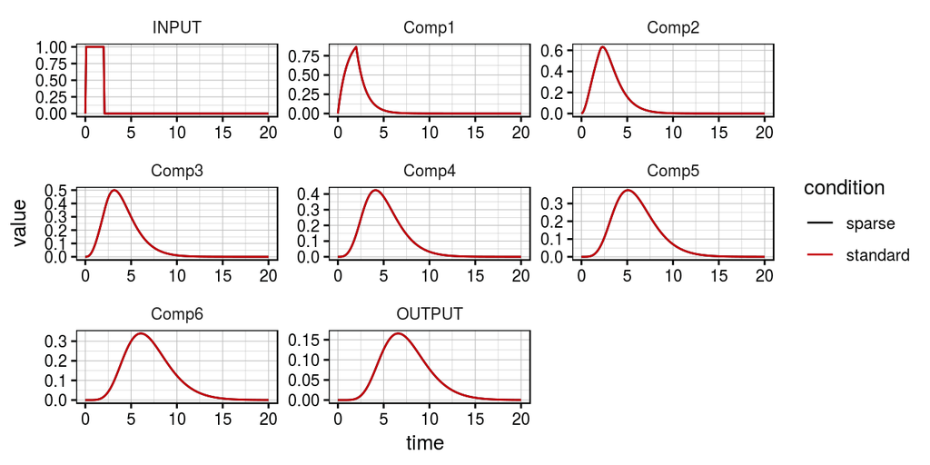

```r
pars <- c(INPUT = 0, Comp1 = 0, Comp2 = 0, Comp3 = 0, Comp4 = 0, Comp5 = 0, Comp6 = 0, OUTPUT = 0,
          k_tr = 1, k_degrad = 2)
times <- seq(0, 20, .1)

prediction.sparse <- x.sparse(times, pars, conditions = "sparse")
prediction.standard <- x.standard(times, pars, conditions = "standard")
plot(c(prediction.sparse, prediction.standard))
```

Next, let’s see if the simulation time with the sparse solver is really faster than with the standard solver

```r
system.time(for (i in 1:100) x.sparse(times, pars, deriv = FALSE))
```

```
##    user  system elapsed
##   1.000   1.132   2.148
```

```r
system.time(for (i in 1:100) x.standard(times, pars, deriv = FALSE))
```

```
##    user  system elapsed
##   0.152   0.000   0.151
```

Here, we chose `deriv = FALSE` to avoid that the sensitivity equations are solved alongside the ODE because we are only interested in the different performance in solving the ODE.

## Some remarks

- Have a look at `?cOde::funC` to learn more about specifying the Jacobian of ODEs which can be used by some solvers. Have a look at `?deSolve::lsoda` and `?deSolve::lsodes` to learn all about the possible options that can be passed to the solver via `optionsOde` or `optionsSens`.
- When the ODE and the sensitivity equations are solved simultaneously (with `deriv = TRUE`), dMod uses `lsodes` by default because it is really faster for large ODE systems!

**Happy solving!!**